# Applied Economics 3611

Environmental and Natural Resource Economics

## Questions set #2

## Preparation for quiz #2

**1.** Company A, the polluter, is located upstream of Company B, the victim, on a certain river. A productive activity pollutes the water, thereby negatively affecting the value of water to B. A’s marginal abatement cost is $\text{MAC} = 12-E$, where $E$ is the amount of emissions. B’s marginal pollution damages from emissions are $\text{MPD}=2E$.

1. If polluter A has the right to the river, what is the total damage to B *in the absence of bargaining?*
2. Draw the MAC and MPD curves in the figure. Use shading on your graph to indicate the damages to firm B at the solution from part a.

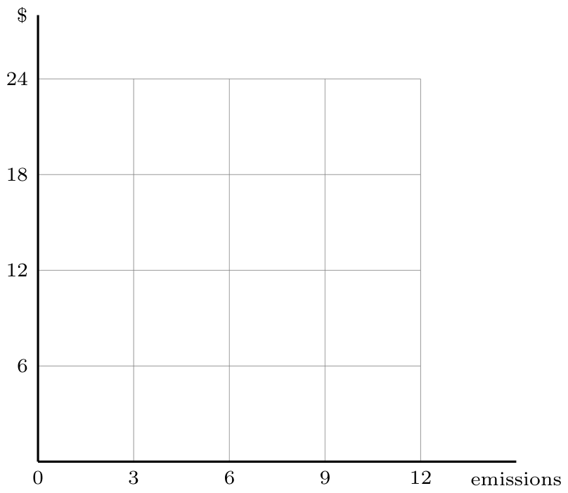

3. Now suppose victim B has the right to the river. What will be the observed level of emissions from polluter A, in the absence of bargaining? If the transactions costs of bargaining are zero, how much pollution will A emit after bargaining? What will be the net social benefit from bargaining? Indicate this SNB in the new graph.

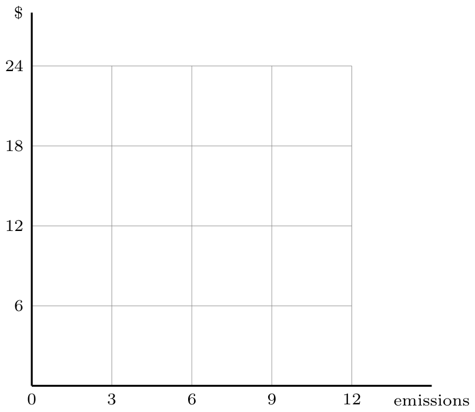

**2.** Two firms are the only emitters of pollution, $E$. In the beginning, each firm emits $E^0=150$, so total emissions start at $E=E_1+E_2=300$. Their marginal abatement curves are
$$\text{MAC}_1=75-\frac{E_1}{2} \qquad\text{and}\qquad
\text{MAC}_2=50-\frac{E_2}{3} ,$$
where $E_1$ is firm 1’s emissions and $E_2$ is firm 2’s emissions.

1. (*4 points*) In the following graph, draw the two MAC curves. Label the MACs and indicate the horizontal and vertical intercepts for both lines.

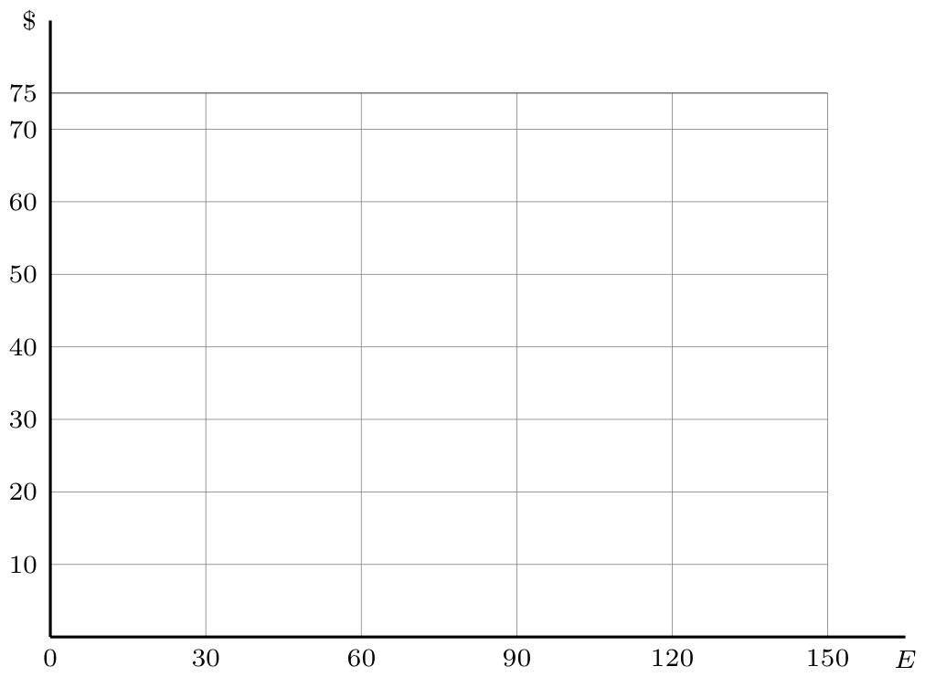

2. (*6 points*) Suppose the EPA requires both firms to reduce emissions by 90, from $E=150$ all the way down to the same emissions level of $E=60$. That is, $E_1= 60$ and $E_2=60$. Total emissions fall by 180, from the initial total of 300 down to 120. What will be the cost to each firm of achieving this level of abatement? Add your cost numbers together to get the aggregate abatement cost for the 2-firm industry, $\text{TAC} = \text{TAC}_1+\text{TAC}_2$.
3. (*5 points*) Now suppose the EPA again decides to reduce emissions from 300 down to 120, but in an efficient manner. What is the socially optimal, or least-cost, distribution of emissions across the two firms? Your answer will be two emission levels, $E_1^*$ for firm 1 and $E_2^*$ for firm 2, where the “*” refers to the optimal outcome. What are $\text{TAC}_1$, $\text{TAC}_2$, and aggregate TAC at this outcome?
4. (*5 points*) Finally, suppose the EPA again decides to achieve a total reduction of 180 units, from 300 to 120, but it decides to use an emissions tax. What is the required level of the tax? How much tax revenue will each polluter pay?

**3** Public Goods game

Play the [public goods game](https://justinandrewjohnson.com/teaching/apec_3611/games/public_goods_game.html) on our website.

1. (*5 points*) Play the game for 10 turns on the default settings. Which strategy maximizes your own return?
2. (*5 points*) Now play the game for 10 rounds again but change the bot behavior to “Conditional Cooperator.” Try to get as high of a score over 10 rounds as possible. What changed in your strategy? Describe why this worked/failed. Does this better mimic real life?
3. (*5 points*) With the conditional cooperator bot, see if you can improve your score by using any of the Institutional Mechanisms (punishing or rewarding the bots). Paste a screenshot of your best score (overall winner in class gets 5 Class Points).